# MG205: Econometrics Theory and Applications

Topic 3: Multivariate Regression Model

José Ignacio González-Rojas

j.i.gonzalez-rojas@lse.ac.uk

London School of Economics and Political Science

# The Real World Has Many Variables

## All Models Are Wrong, Some Are Useful — George Box

### We Cannot Capture Full Complexity

#### The Challenge We Face

- The world is **messy and interconnected**
- Everything affects everything
- We cannot *measure* all variables
- We cannot *include* all variables

#### How We Respond

- *Narrow down our model*
- Focus on specific relationships
- Make sensible, defensible assumptions
- Justify every variable choice

Models approximate reality to answer specific questions

## Simple Regression Cannot Handle Confounders

### Population Models: From One to Many Explanatory Variables

#### Simple Linear Regression

$$Y_i = \beta_0 + \beta_1 X_i + e_i$$

- **Clear interpretation:** $\beta_1$ is the slope
- Often too restrictive
- Suffers from omitted variable bias

#### Multiple Regression

$$Y_i = \beta_0 + \beta_1 X_{i1} + \beta_2 X_{i2} + u_i$$

- $\beta_1$ measures effect **holding $X_2$ constant**
- More realistic
- Addresses confounding

# **Exercise 1:** What Does “Controlling” Mean?

## Controlling Holds $x_2$ Fixed

### Residualisation does not establish exogeneity

#### Holding constant

- How does the **fitted outcome** change with $x_1$, holding $x_2$ fixed?

#### Using remaining variation

- Fit $x_1$ using $x_2$ and an intercept.
- Use the residual part, uncorrelated with $x_2$ in this sample.

#### Separating the modelled term

- Including $x_2$ represents its linear contribution explicitly.
- This does **not** guarantee exogeneity or remove all confounding.

# **Exercise 2:** Discuss the Interpretation of Multiple Regression

## The Partial Derivative Holds $x_2$ Constant

### Interpretation of the fitted regression

#### Fitted value

$$\hat y_i=\hat\beta_0+\hat\beta_1x_{i1}+\hat\beta_2x_{i2}.$$

#### Partial slope

$$\frac{\partial\hat y_i}{\partial x_{i1}}=\hat\beta_1.$$

- $x_2$ held fixed.
- Fitted coefficients held fixed.

## Observed $x_1$ Is Its Linear Fit Plus a Residual

### Define the auxiliary fit; centre it using MP3

#### Auxiliary OLS and its residual

$$\begin{aligned}
\hat x_{i1}&=\hat a_0+\hat a_1x_{i2},\\
\hat v_i&=x_{i1}-\hat x_{i1}.
\end{aligned}$$

$$x_{i1}=\underbrace{\hat x_{i1}}_{\text{fitted part}}
+\underbrace{\hat v_i}_{\text{residual part}}.$$

#### Centred decomposition: MP3

$$\hat a_0=\bar x_1-\hat a_1\bar x_2.$$

$$\begin{aligned}
x_{i1}-\bar x_1&=\hat a_1(x_{i2}-\bar x_2)\\
&\quad+\hat v_i.
\end{aligned}$$

**No exact collinearity:** $\sum_i\hat v_i^2>0$.

## The $x_1$–Residual Cross-Product Is $\sum_i\hat v_i^2$

### Auxiliary MP1 and MP2 remove the fitted part

#### Zero sample covariance

$$\begin{aligned}
\sum_i\hat v_i&=0,\quad\bar{\hat v}=0 &&\text{(MP1)},\\
\sum_i x_{i2}\hat v_i&=0 &&\text{(MP2)}.
\end{aligned}$$

$$\begin{aligned}
&\sum_i(x_{i2}-\bar x_2)(\hat v_i-\bar{\hat v})\\
&=\sum_i x_{i2}\hat v_i-\bar x_2\sum_i\hat v_i\\
&=0.
\end{aligned}$$

#### Substitute the decomposition

$$\begin{aligned}
\sum_i\hat v_i x_{i1}
&=\hat a_0\sum_i\hat v_i\\
&\quad+\hat a_1\sum_i x_{i2}\hat v_i\\
&\quad+\sum_i\hat v_i^2.
\end{aligned}$$

$$\boxed{\sum_i\hat v_i x_{i1}=\sum_i\hat v_i^2}\quad\text{(1)}.$$

## The Two Regression Residuals Are Orthogonal

### Full-regression MP1 and MP2 justify each cancellation

#### Full-regression residual

$$\hat\varepsilon_i=y_i-\hat y_i.$$

$$\begin{aligned}
\sum_i\hat\varepsilon_i&=0 &&\text{(MP1)},\\
\sum_i x_{i1}\hat\varepsilon_i&=0 &&\text{(MP2)},\\
\sum_i x_{i2}\hat\varepsilon_i&=0 &&\text{(MP2)}.
\end{aligned}$$

#### Substitute the auxiliary residual

$$\hat v_i=x_{i1}-\hat a_0-\hat a_1x_{i2}.$$

$$\begin{aligned}
\sum_i\hat v_i\hat\varepsilon_i
&=\underbrace{\sum_i x_{i1}\hat\varepsilon_i}_{0\;\text{(MP2)}}\\
&\quad-\hat a_0\underbrace{\sum_i\hat\varepsilon_i}_{0\;\text{(MP1)}}
-\hat a_1\underbrace{\sum_i x_{i2}\hat\varepsilon_i}_{0\;\text{(MP2)}}\\
&=0\qquad\text{(2)}.
\end{aligned}$$

## Residualising Removes the Intercept and $x_2$ Terms

### Multiply the fitted identity by $\hat v_i$; use (1) and (2)

#### Multiply and sum

$$y_i=\hat\beta_0+\hat\beta_1x_{i1}+\hat\beta_2x_{i2}+\hat\varepsilon_i.$$

$$\begin{aligned}
\sum_i\hat v_i y_i
&=\underbrace{\hat\beta_0\sum_i\hat v_i}_{0\;\text{(auxiliary MP1)}}
+\hat\beta_1\sum_i\hat v_i x_{i1}\\
&\quad+\underbrace{\hat\beta_2\sum_i\hat v_i x_{i2}}_{0\;\text{(auxiliary MP2)}}
+\underbrace{\sum_i\hat v_i\hat\varepsilon_i}_{0\;\text{by (2)}}.
\end{aligned}$$

#### Substitute identity (1)

$$\sum_i\hat v_i x_{i1}=\sum_i\hat v_i^2.$$

$$\begin{gathered}
\boxed{\sum_i\hat v_i y_i=\hat\beta_1\sum_i\hat v_i^2}\\
\text{(3)}.
\end{gathered}$$

## The Simple-OLS Slope Equals $\hat\beta_1$

### Regress the unchanged outcome on residual $x_1$ and an intercept

#### Second-stage OLS fit

$$y_i=\hat c+\hat\theta\hat v_i+\hat r_i.$$

#### Auxiliary MP1

$$\bar{\hat v}=0,\qquad\sum_i\hat v_i=0.$$

**No exact collinearity:** $\sum_i\hat v_i^2>0$.

#### Ordinary OLS slope

$$\begin{aligned}
\hat\theta
&=\frac{\sum_i(\hat v_i-\bar{\hat v})(y_i-\bar y)}
{\sum_i(\hat v_i-\bar{\hat v})^2}\\
&=\frac{\sum_i\hat v_i y_i-\bar y\sum_i\hat v_i}{\sum_i\hat v_i^2}\\
&=\frac{\sum_i\hat v_i y_i}{\sum_i\hat v_i^2}
=\hat\beta_1\quad\text{by (3)}.
\end{aligned}$$

# **Exercise 3:** CEO Compensation and Omitted Variable Bias

## Firm Profits Affect CEO Salary, But What About Business Environment?

### Understanding When Omitted Variables Create Bias

$$\log(\text{salary}_i) = \beta_0 + \beta_1 \cdot \text{profits}_i + e_i$$

- What about $\text{environment}_i$ (quality of business environment)?
  - The economy grows
  - Business environment improves
  - Firms make more profits
  - CEOs have better outside options → must be paid more

Does omitting environment create bias? What is the direction?

## Omitted Variable Bias Arises When Two Conditions Hold

### Understanding the Bias Mechanism Through Assumptions

#### Consider the true model

$$Y_i = \beta_0 + \beta_1 X_{i1} + \beta_2 X_{i2} + e_i$$

#### But we estimate

$$y_i = \gamma_0 + \gamma_1 x_{i1} + u_i$$

#### The omitted term enters the error

$$u_i = \beta_2 X_{i2} + e_i$$

#### For unbiasedness, we need

$$\mathbb{E}[u_i \mid X_{i1}] = 0$$

#### But this requires

$$\mathbb{E}[\beta_2 X_{i2} + e_i \mid X_{i1}] = 0$$

#### Which fails when

$$\mathbb{E}[X_{i2} \mid X_{i1}] \neq 0$$

This means $X_{i1}$ and $X_{i2}$ are correlated!

## Visualising the Omitted Variable Problem

### The Causal Structure Shows Direct and Indirect Effects

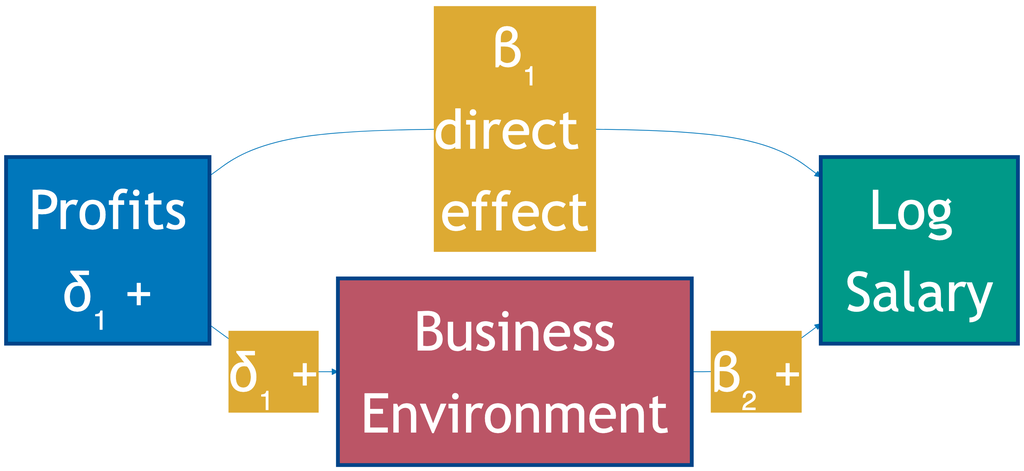

## Omitted Variable Bias Requires Two Correlations

### Both Conditions Exist in Our CEO Compensation Case

#### Omitted variable affects included variable

$$\operatorname{cov}(\text{environment}_i, \text{profits}_i) > 0$$

- Good business environment → companies sell more
- Higher revenues → higher profits
- **$\delta_1 > 0$**

#### Omitted variable affects outcome

$$\operatorname{cov}(\text{environment}_i, \log(\text{salary}_i)) > 0$$

- Better environment → CEOs have better outside offers
- Competition increases → firms pay more
- **$\beta_2 > 0$**

$\therefore$ Both correlations exist: omitted variable bias is present

## Bias Is Positive, Our Estimate Is an Upper Bound

### The Omitted Variable Bias Formula Reveals Direction

$$\text{Bias}(\hat{\beta}_1) = \underbrace{\beta_2}_{+} \times \underbrace{\delta_1}_{+}$$

- $\beta_2$: Effect of $\text{environment}_i$ on $\log(\text{salary}_i)$ in the full model
- $\delta_1$: Effect of $\text{profits}_i$ on $\text{environment}_i$ in auxiliary regression

#### Economic Interpretation

$$\mathbb{E}[\hat{\beta}_1] = \beta_1 + \underbrace{(+)}_{\text{positive bias}}$$

- Our estimate $\hat{\beta}_1$ will be **too high**
- It’s an **upper bound**, not a lower bound
- True effect of profits is **smaller** than our estimate

# **Exercise 4:** Testing for Omitted Variable Bias Using Residuals

## Sample Residuals Cannot Detect Bias

### A Common Mistake in Applied Work

We ran simple OLS of $y$ on $x$. Worried about omitted variable bias, we check:

$$\sum_{i=1}^n x_i \hat{\varepsilon}_i = 0$$

We find this holds in our sample.

Does this evidence suggest there is **no** omitted variable bias?

**Answer:** **No**, this evidence tells us nothing about omitted variable bias.

## OLS Mechanics Do Not Establish Exogeneity

### Unobserved errors and computed residuals are different objects

| Concept | Population | Sample |
| --- | --- | --- |
| **Error / residual** | $e_i$: unobserved model error | $\hat\varepsilon_i$: computed residual |
| **Conditional mean** | $\mathbb E[e_i\mid X_i]=0$: assumption | Not established by residual orthogonality |
| **Orthogonality** | $\mathbb E[X_i e_i]=0$: implied by exogeneity | $\sum_i x_i\hat\varepsilon_i=0$: MP2 |
| **Across samples** | Parameters fixed; errors can vary | Estimates and residuals can vary |

# **Exercise 5:** $R^{2}$ with Additional Variables

## $R^{2}$ Never Decreases with More Variables

### Why Model Fit Always Improves

$$R^2 = \frac{\sum_{i=1}^n(\hat{y}_i - \bar{y})^2}{\sum_{i=1}^n(y_i - \bar{y})^2} = \frac{\text{Explained Sum of Squares}}{\text{Total Sum of Squares}}$$

#### With Fewer Variables

$$\text{earnings}_i = \beta_0 + \beta_1 \cdot \mathbb{1}[i \text{ is female}] + e_i$$

- All males get same $\hat{y}$
- All females get same $\hat{y}$
- Only 2 distinct predictions

#### With More Variables

$$\begin{align*}
\text{earnings}_i &= \gamma_0 + \gamma_1 \cdot \mathbb{1}[i \text{ is female}] \\
&+ \gamma_2 \cdot \text{education}_i + u_i
\end{align*}$$

- Males differ by education
- Females differ by education

## More Variables Increase Coefficient Variance

### The Cost of Controlling

$$\operatorname{var}(\hat{\beta}_j\mid\mathbf{x}) = \frac{\sigma^2}{ns_{x_j}^2(1-R_j^2)},$$

where $\mathbf{x}=(x_{i\ell})_{i=1,\ldots,n;\,\ell=1,\ldots,k}$ is the complete observed design, $s_{x_j}^2=\sum_i(x_{ij}-\bar{x}_j)^2/n$, and $R_j^2$ comes from regressing regressor $j$ on the others. Index $i$ labels observations; $j$ labels coefficients.

#### When We Add $x_2$

- If $x_1$ and $x_2$ are correlated, then $R^2_1 > 0$
- $\therefore 1 - R^2_1 < 1$
- $\operatorname{var}(\hat{\beta}_1)\uparrow$

#### The Intuition

With correlated regressors:

- Harder to separate individual effects
- More uncertainty about each coefficient
- Need larger effects to reject $H_0$

This is the trade-off: better fit ($R^2 \uparrow$) but less precise estimates ($\operatorname{var}(\hat{\beta})\uparrow$)

## The Fundamental Trade-off: Fit vs Precision

### Two Dimensions Cannot Be Simultaneously Optimised

| Dimension | What It Measures | Impact of More Controls |
| --- | --- | --- |
| **Goodness of Fit** | How well does model explain variation? | $R^2$ increases → better predictions |
| **Hypothesis Testing** | Can we detect effects? | $\operatorname{var}(\hat{\beta})\uparrow$ → wider confidence intervals → harder to reject $H_0$ |

#### The Dilemma

- **Adding variables**: Improves $R^2$ but increases $\operatorname{var}(\hat{\beta})$
- **Dropping variables**: Risks omitted variable bias

Choose based on research question: Do you prioritise explanation or causal inference?

# **Exercise 6:** Reducing Variance of Estimators

## Only Sample Size Reduces Variance Reliably

### What Can We Do About High Variance?

$$\operatorname{var}(\hat{\beta}_j\mid\mathbf{x}) = \frac{\sigma^2}{ns_{x_j}^2(1-R_j^2)}$$

#### Increase sample size ✓

- $n\uparrow$ directly
- $\implies$ Variance $\downarrow$
- **Only reliable solution**

#### Choose $x$ far from mean? ✗

- Would increase $s_{x_1}^2$
- Conflicts with random sampling (Assumption 2)
- Cannot control $x$ values

#### Drop $x_2$? ✗

- Removes $(1 - R^2_1)$ term
- Creates bias if $R^2_1 > 0$
- Net effect ambiguous

## Bias vs Variance Cannot Both Be Minimised

### The Fundamental Tradeoff When Omitting Variables

#### Pros of Dropping Variables

- Lower $\operatorname{var}(\hat{\beta}_k)$
- Narrower confidence intervals
- Easier to detect effects

#### Cons of Dropping Variables

- Potential omitted variable bias
- Estimates may be misleading due to confounding
- Cannot interpret causally
- Worse model fit (lower $R^2$)

# **Exercise 7:** Low Variance and BLUE

## Low Variance Concentrates Estimates

### Why Estimator Variance Matters

#### Low Variance Estimator

- **Values across samples:** 0.08, 0.09, 0.10, 0.09, 0.08
- Concentrated around $\mathbb{E}[\hat{\beta}]$
- If also unbiased: close to $\beta$ most of the time
- Reliable in practice

#### High Variance Estimator

- **Values across samples:** -0.50, 0.02, 0.80, -0.20, 0.15
- Widely dispersed, even if unbiased on average
- Might be far from $\beta$ in any sample
- Unreliable in practice

Low variance + unbiasedness = estimates we can trust

## OLS Has Lowest Variance Among Unbiased Estimators

### The Gauss-Markov Theorem

**Theorem 1 (Gauss-Markov Theorem)** Under Assumptions 1-6, OLS is **B**est **L**inear **U**nbiased **E**stimator.

#### What Each Term Means

- *Linear:* Estimator is linear in $y$ values
- *Unbiased:* $\mathbb{E}[\hat{\beta}] = \beta$
- *Best:* Lowest variance

#### Why This Matters

Among the **class of (all)** linear unbiased estimators, OLS has:

$$\operatorname{var}(\hat{\beta}_{\text{OLS}}) \leq \operatorname{var}(\hat{\beta}_{\text{other}})$$

# Putting It All Together

## Model Selection Requires Theoretical Justification

### Practical Guidance for Choosing Variables

#### Include Variables When:

1. **Theoretically important** for relationship
2. **Correlated** with both $y$ and your $x$ of interest
3. **Measurable** and available

#### Do NOT Include Just Because

1. They’re available in data
2. They increase $R^2$
3. Someone else included them
4. They make results “look better”

Start with theory → specify model → justify choices → check robustness

## What You Must Take Away from Today

# Next Week

## Next Class: Empirical Exercise 7

### Daughters Change How Legislators Vote on Women’s Issues

**Paper:** “Female Socialisation: How Daughters Affect Their Legislator Fathers’ Voting on Women’s Issues”

**Author:** Ebonya L. Washington  
**Journal:** *American Economic Review*, 2008

**Research question:** Do daughters make fathers more feminist?

**Method:** Controlling for total children, each daughter increases legislator’s propensity to vote liberally on reproductive rights.

**Why it matters:** Identifies child-to-parent behavioural influence in high-stakes decisions.

Reading week next week!